# Guide to Data Visualization in R

Author

Brian Lookabaugh

R offers one of the best opportunities for data visualization in the data analytics/data science industry. Using the `ggplot()` command, one can build highly customized visualizations. While visualizations using ggplot can appear long and complicated in syntax, the logic of the syntax itself is quite simple. In this document, we will first go over the options provided using ggplot to customize various scatter plots. After this, we will create numerous different types of popular visualizations including histograms, density plots, box plots, bar charts, and maps.

First, let us load the required packages:

```r
library(tidyverse) # Data Manipulation and Visualization
```

For the purposes of this demonstration, we are going to be using a built-in data set in R, the “mtcars” data. We are going to also convert vehicle names to columns since they will be of use later on this data set:

```r
data("mtcars")

mtcars <- mtcars %>%
  rownames_to_column(var = "car_name")
```

## Basic Scatter Plot Customization

Here, we will begin by creating a scatter plot (called “scatter”) with miles per gallon (“mpg”) on the y-axis, horsepower (“hp”) on the x-axis, and whether a vehicle has manual or automatic transmission (“am”) coded by color. We are also going to include a linear regression line with confidence intervals displayed to visualize the direction and size of the relationship between mpg and horsepower. Lastly, we are going to appropriately label this graph. Let’s see what this scatterplot looks like:

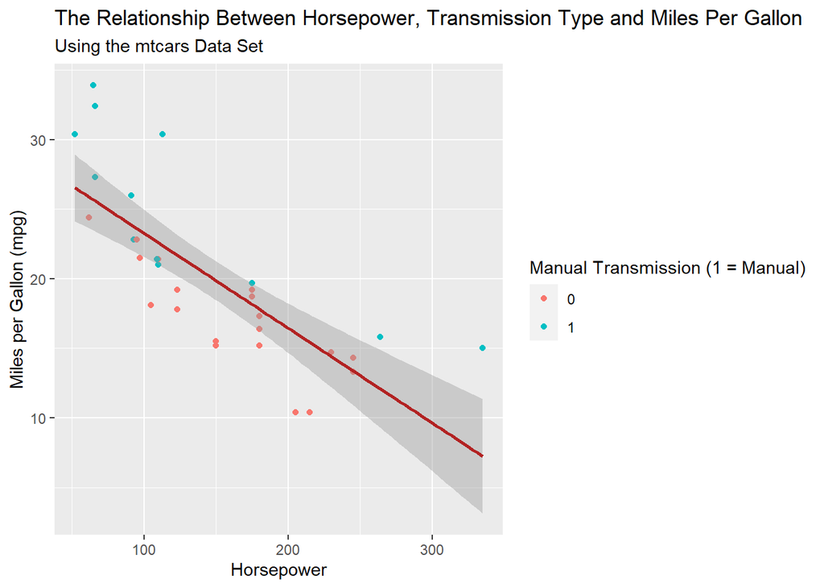

```r
scatter <- ggplot(mtcars,
  aes(x = hp, y = mpg)) +
  geom_point(aes(col = factor(am))) + # Using "factor" here to tell R that is is a categorical variable
  geom_smooth(method = "lm", col = "firebrick") +
  labs(title = "The Relationship Between Horsepower, Transmission Type and Miles Per Gallon",
       subtitle = "Using the mtcars Data Set",
       y = "Miles per Gallon (mpg)",
       x = "Horsepower",
       color = "Manual Transmission (1 = Manual)")
plot(scatter)
```

### Adjusting Axis Ranges

This looks like a decent enough graph. But let’s say that, for whatever reason, we are only interested in vehicles with horsepower below 300. One way that we could deal with this would be to create a new data frame excluding the single observation that has more than 300 horsepower. However, we also have an option to adjust the axis scales instead. Note that we will not have to specify everything (labels, what values are on the x and y axes, etc.) this time because we have already specified that prior and saved it to the `scatter` object.

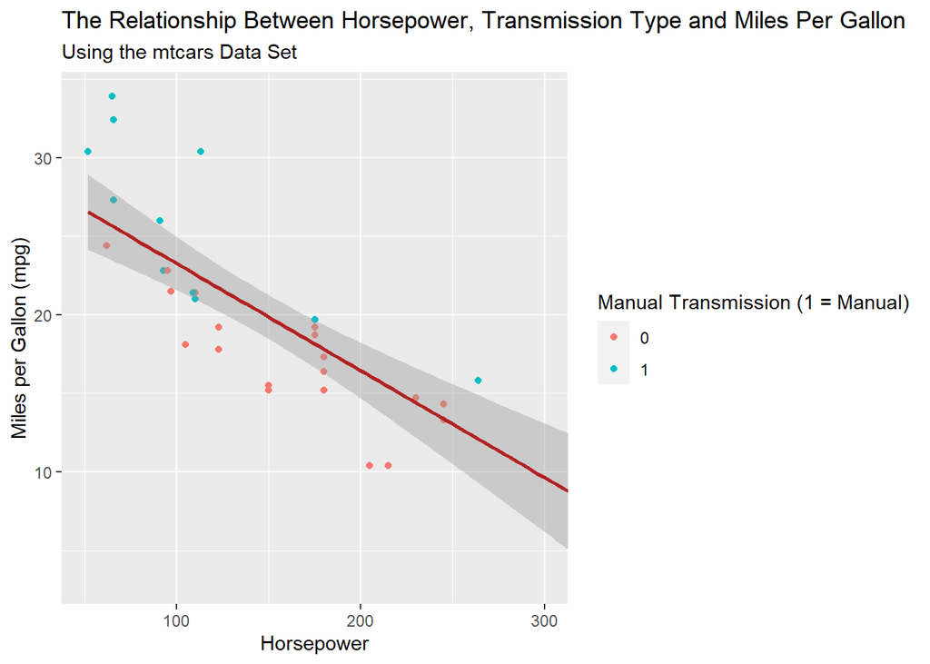

```r
scatter2 <- scatter +
  coord_cartesian(xlim = c(50, 300))
plot(scatter2)
```

### Changing Color and Point Sizes

We may be unsatisfied with the default color and point size options that ggplot provides. Luckily for us, there are many customizable options. I am particularly partial to the color palettes provided in the “viridis” package. Indeed, the color palettes provided here are quite popular in the R community as a whole in part due to their color blind accessibility. We are going to explore color customization with this package. First, we will need to load it:

```r
library(viridis)
```

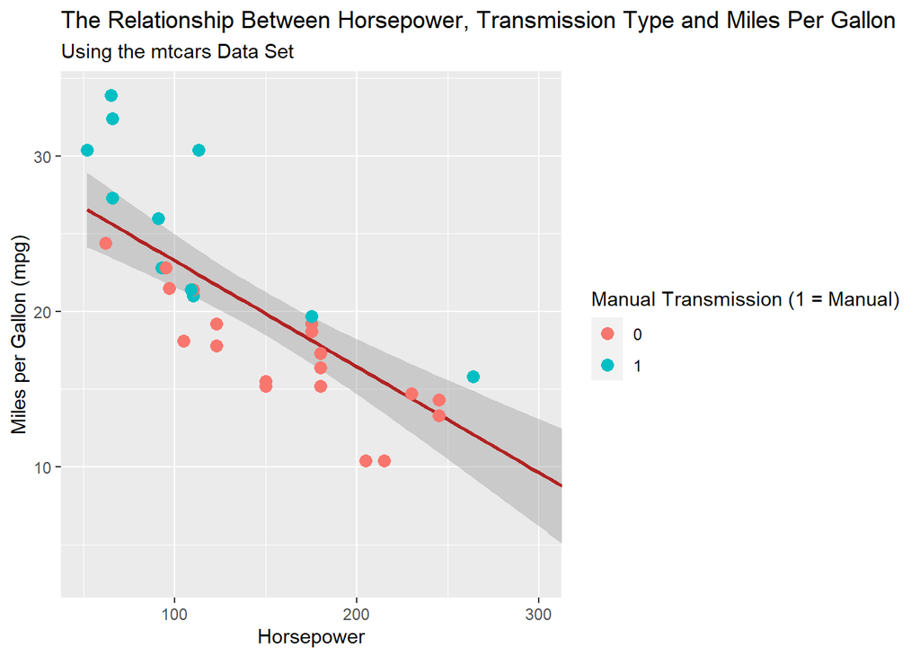

```r
scatter3 <- scatter2 +
  geom_point(aes(col = factor(am)), size = 3)
plot(scatter3)
```

While this syntax changed the size of the points, the color of the points has remained the same. To alter this, we can select an alternative color palette:

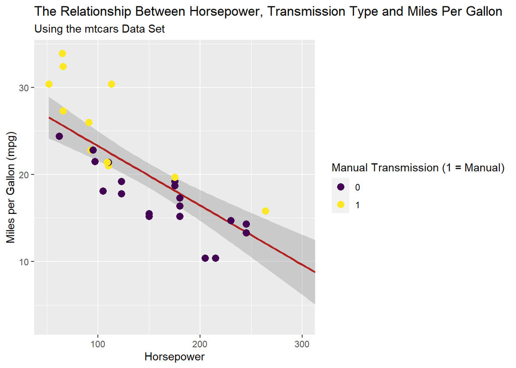

```r
scatter4 <- scatter3 +
  scale_color_viridis(discrete = TRUE)
plot(scatter4)
```

Let’s get a more comprehensive idea of the virids color palette by changing our discrete color-assigned categorical value to something with more unique values. Let’s use the number of carburetors instead:

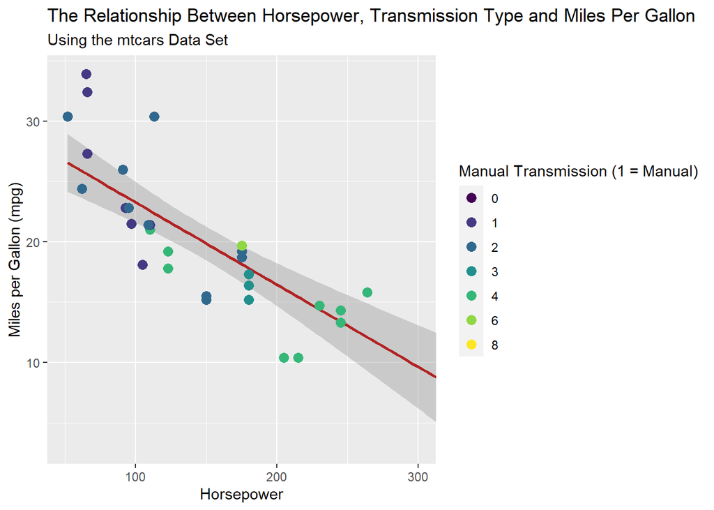

```r
scatter5 <- scatter2 +
  geom_point(aes(col = factor(carb)), size = 3) +
  scale_color_viridis(discrete = TRUE)
plot(scatter5)
```

### Themes

Alternatively, if we do not want to be responsible for the complete customization of our plot, we can rely on themes. We can do this through two means. For one, we can set the theme so that all of the visualizations in our document will have the same theme that we do not have to specify for each individual visualization:

```r
theme_set(theme_dark())
```

Now, if we plot `scatter5`, we should be able to see the dark theme applied:

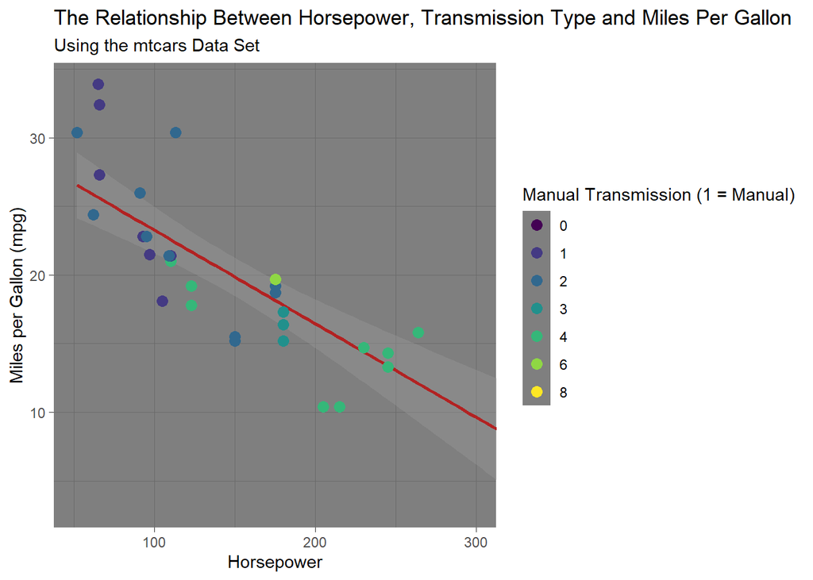

```r
plot(scatter5)
```

This isn’t the nicest looking plot. Instead, we will simply specify the theme we are wanting to use in our visualization. We will be using the black and white theme instead. After we specify this within the scatter plot code specifically, we will go ahead and set the theme to black and white as well:

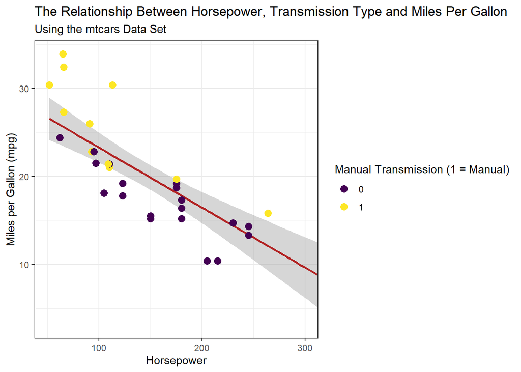

```r
scatter6 <- scatter4 +
  scale_color_viridis(discrete = TRUE) +
  theme_bw()
plot(scatter6)
```

```r
theme_set(theme_bw())
```

### Adjusting X and Y Axis Units

Recall that, in the prior graphs, the units on both the x and y axes are pre-determined (intervals of 10 on the y-axis and intervals of 100 on the x-axis). This is another aspect of our plot that we may wish to customize. Here, we are going to change the x-axis to include intervals of 50 for its ticks and change the y-axis to include intervals of 5 for its ticks:

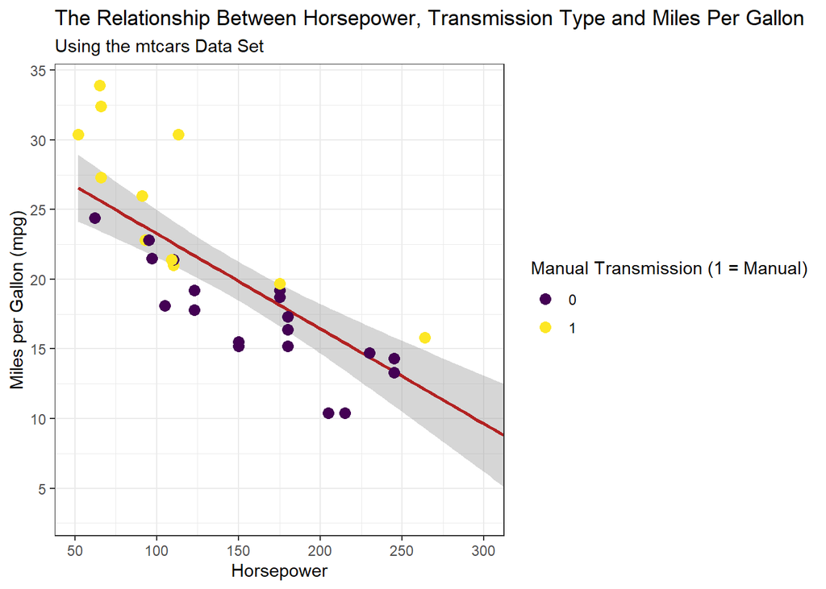

```r
scatter7 <- scatter6 +
  scale_x_continuous(breaks = seq(50, 300, 50)) +
  scale_y_continuous(breaks = seq(0, 35, 5))
plot(scatter7)
```

### Customized Titles

We may also wish to completely modify every aspect of our text included in our graph. For example, we may wish to change the font type, the font size, etc. We will play around with this feature below:

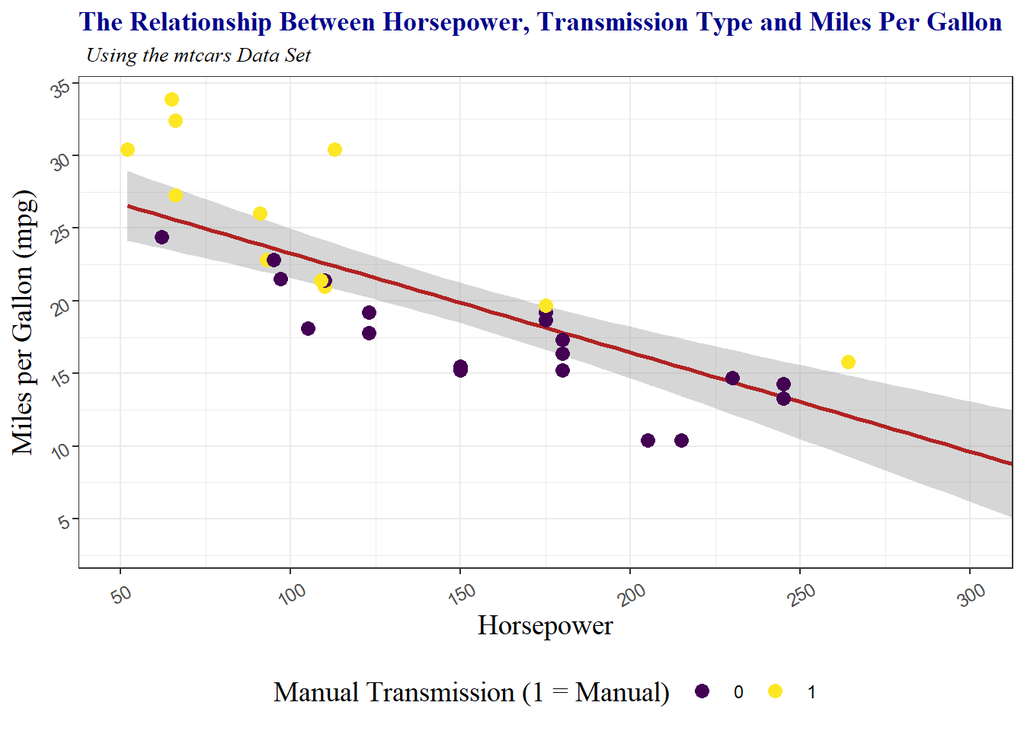

```r
scatter8 <- scatter7 +
  theme(
    plot.title = element_text(
      size = 13,
      face = "bold",
      family = "serif",
      color = "dark blue"),
    plot.subtitle = element_text(
      size = 10,
      face = "italic",
      family = "serif",
      hjust = 0.01),
    legend.position = "bottom",
    legend.box = "horizontal",
    legend.title = element_text(
      size = 14,
      family = "serif"),
    axis.title.x = element_text(
      size = 14,
      vjust = 1,
      family = "serif"),
    axis.title.y = element_text(
      size = 14,
      vjust = 1,
      family = "serif"),
    axis.text.x = element_text(
      size = 9,
      angle = 30,
      vjust = 0.5),
    axis.text.y = element_text(
      size = 9,
      angle = 30,
      vjust = 0.5)
    )
plot(scatter8)
```

### Legend Customization

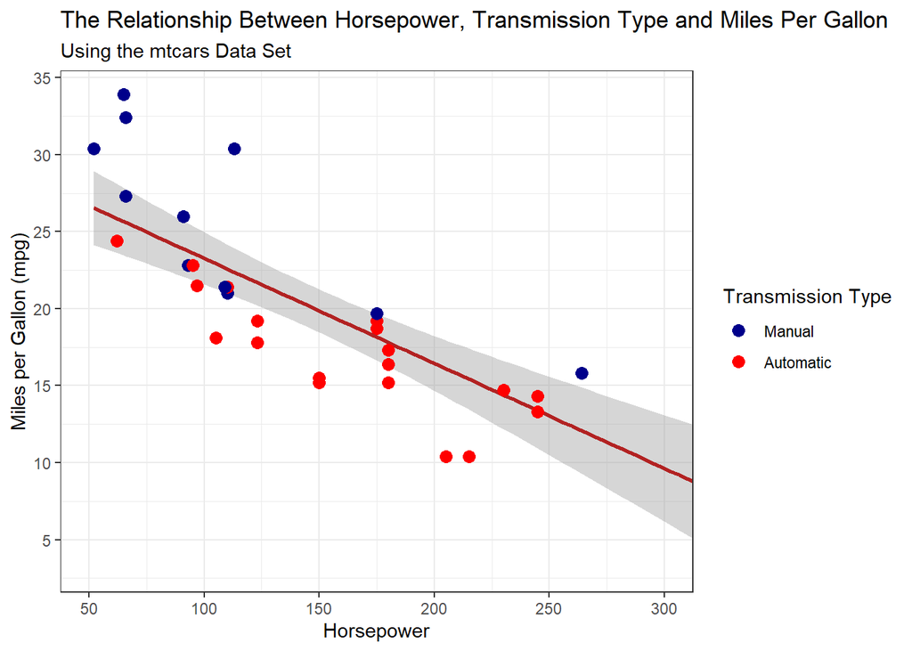

```r
scatter9 <- scatter7 +
  scale_color_manual(
    name = "Transmission Type",
    labels = c("Manual",
               "Automatic"),
    values = c("1" = "dark blue",
               "0" = "red"))
plot(scatter9)
```

### Labeling Points

Especially when dealing with outliers, we may wish to label specific points within the scatterplot. Below represents the syntax for how to do this, where we are labeling our point that has a horsepower greater than 250. First, to ensure that our labels do not appear too cluttered, we are going to load the `ggrepel` package (which, in practice is more useful when you are labeling more than one point):

```r
library(ggrepel) # Better labeling of points in a plot
```

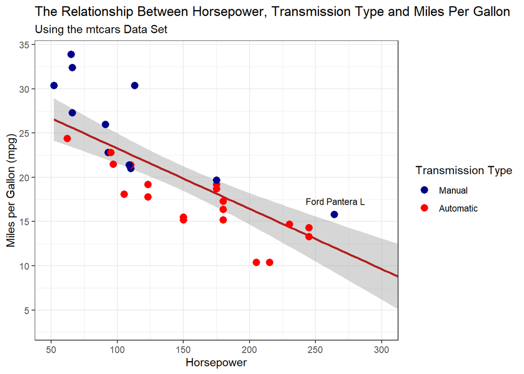

```r
scatter10 <- scatter9 +
  geom_text_repel(
    data = subset(mtcars, hp > 250 & hp < 300),
    aes(label = car_name),
    size = 3,
    nudge_y = 1.5,
    nudge_x = 0.8)
plot(scatter10)
```

What we have done here is discovered that the car with the highest horsepower in the data set (barring the vehicle that we zoomed away from earlier) is a Ford Pantera L. You can play around with the `nudge_y` and `nudge_x`features as these allow you to place the label exactly where you would like it to be in a plot.

### Faceting

Lastly, we may be interested in observing variation in our data with a fourth variable considered. Currently, we have primarily been interested in miles per gallon (y-axis), horsepower (x-axis), and transmission type (color). With faceting, we can keep these aesthetic features and divide our data into different groups to examine how these patterns may differ between differing groups. Let’s see if the relationship between mpg, horsepower and transmission type varies based on the number of cylinders:

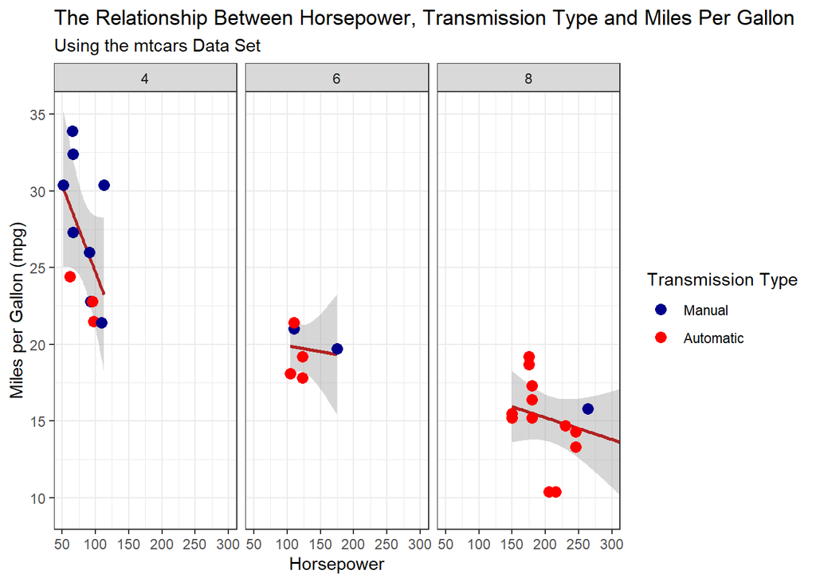

```r
scatter11 <- scatter9 +
  facet_wrap(~ cyl)
plot(scatter11)
```

We can also edit some of the things in this plot that may need attention, such as point size and the ranges of the x and y axes:

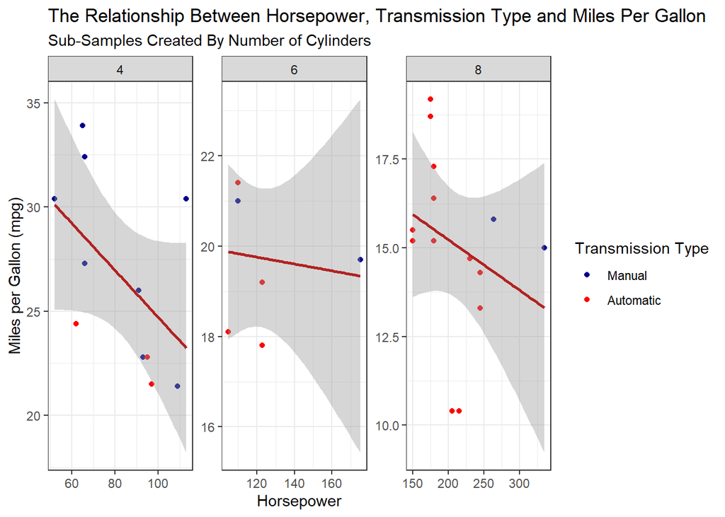

```r
scatter12 <- scatter +
  labs(subtitle = "Sub-Samples Created By Number of Cylinders") +
  scale_color_manual(
    name = "Transmission Type",
    labels = c("Manual",
               "Automatic"),
    values = c("1" = "dark blue",
               "0" = "red")) +
  facet_wrap(~ cyl, scales = "free")
plot(scatter12)
```

## Histograms and Density Plots

Histograms are helpful tools for visualizing the frequency of values and examining the distribution of data. First, we are going to examine the distribution of vehicle weight. After this, we are going to look at how to include the distributions of numerous values for a single variable within a single plot. Note that I am going to include various customized options in these plots to make them look aesthetically pleasing. All of these customized options are explained in the prior section.

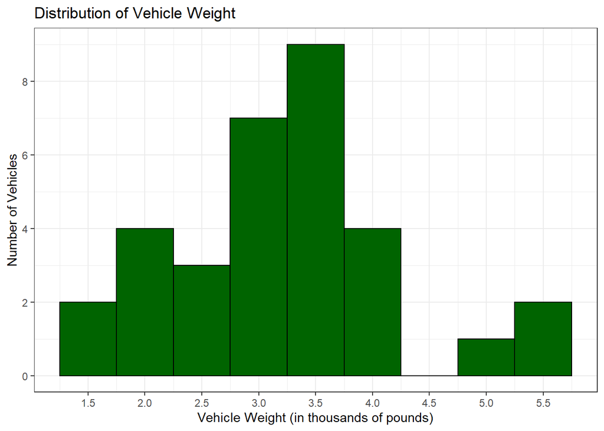

```r
hist1 <- ggplot(mtcars, aes(x = wt)) +
  geom_histogram(
    color = "black",
    fill = "darkgreen",
    binwidth = 0.5) +
  labs(
    title = "Distribution of Vehicle Weight",
    y = "Number of Vehicles",
    x = "Vehicle Weight (in thousands of pounds)") +
  scale_x_continuous(breaks = seq(0, 6, 0.5)) +
  scale_y_continuous(breaks = seq(0, 10, 2))
plot(hist1)
```

We can also generate a histogram overlaid with a density plot:

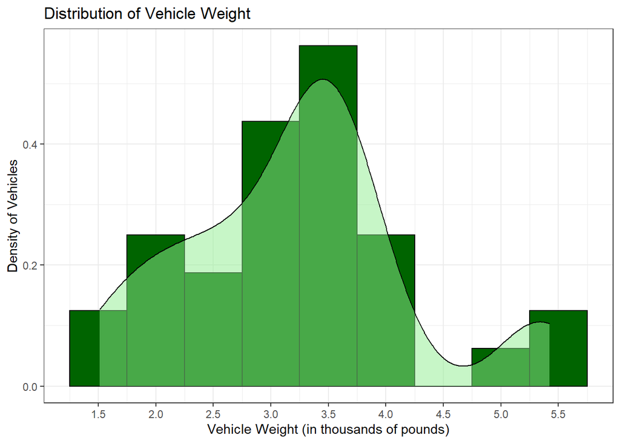

```r
hist2 <- ggplot(mtcars, aes(x = wt)) +
  geom_histogram(
    aes(y = ..density..),
    color = "black",
    fill = "darkgreen",
    binwidth = 0.5) +
  labs(
    title = "Distribution of Vehicle Weight",
    y = "Density of Vehicles",
    x = "Vehicle Weight (in thousands of pounds)") +
  scale_x_continuous(breaks = seq(0, 6, 0.5)) +
  geom_density(
    alpha = .5, fill = "lightgreen")
plot(hist2)
```

Lastly, we may be interested in seeing how the distribution of a variable changes over a certain category. Let’s examine how the distribution of weight varies by the number of cylinders a vehicle has:

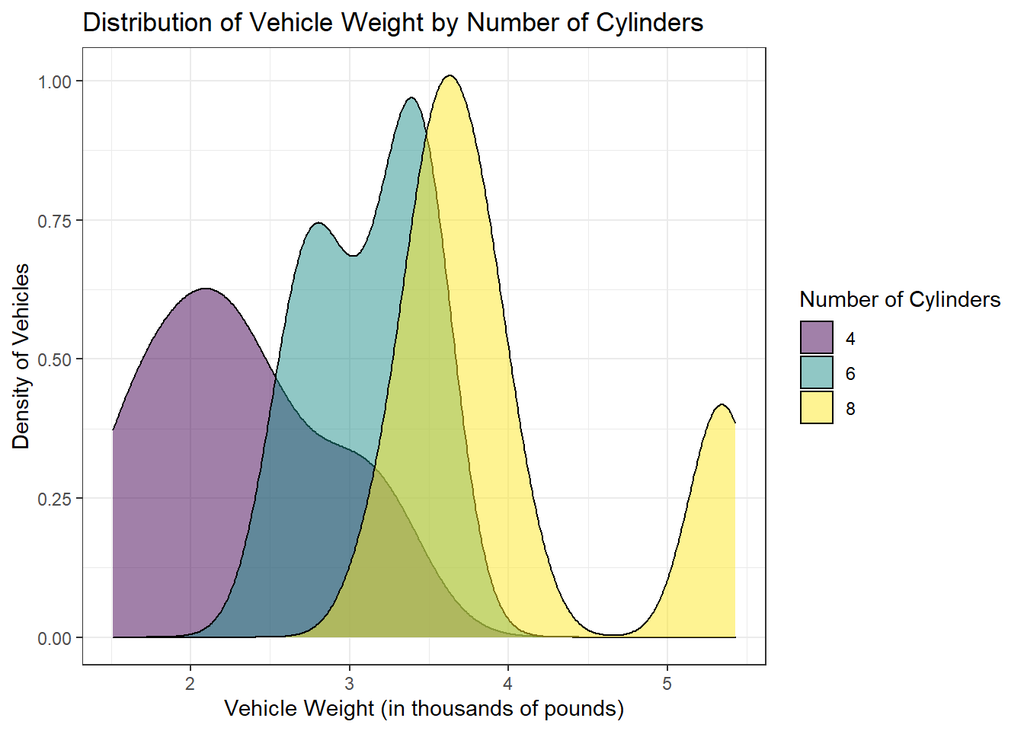

```r
dens1 <- ggplot(mtcars, aes(x = wt)) +
  scale_fill_viridis(discrete = TRUE) +
  geom_density(aes(fill = factor(cyl)), alpha = 0.5) +
  labs(
    title = "Distribution of Vehicle Weight by Number of Cylinders",
    y = "Density of Vehicles",
    x = "Vehicle Weight (in thousands of pounds)",
    fill = "Number of Cylinders")
plot(dens1)
```

## Box-Plots

Box plots are helpful visualization tools that sum a lot of statistical information for the viewer in a single plot. This information includes the distribution of the data, outliers, and the median. Here, we are going to analyze this information for miles per gallon across varying numbers of carburetors that vehicles have:

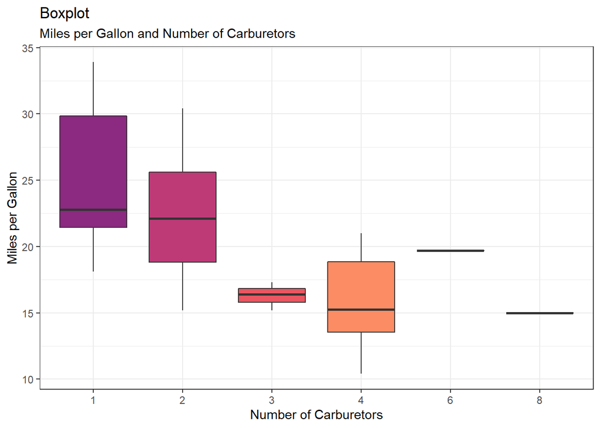

```r
box1 <- ggplot(mtcars,
    aes(x = as.factor(carb),
    y = mpg,
    fill = as.factor(carb))) +
  geom_boxplot() +
  labs(title = "Boxplot",
       subtitle = "Miles per Gallon and Number of Carburetors",
       x = "Number of Carburetors",
       y = "Miles per Gallon") +
  scale_fill_viridis(
    discrete = TRUE,
    option = "magma",
    begin = 0.4) +
  theme(legend.position = "none")
plot(box1)
```

## Bar Charts

Returning to a simpler form of visualization, a bar chart may be sufficient if we wish to view variations in a variable across different categories. Here, we are going to see how miles per gallon varies by vehicle type. We are also going to order the `car_name` variable in a manner so that, in our bar chart, vehicles are listed in ascending order according to their miles per gallon value. In addition, we are going to censor the legend as its information is not needed given the intuitive association between lighter colors and higher values of miles per gallon.

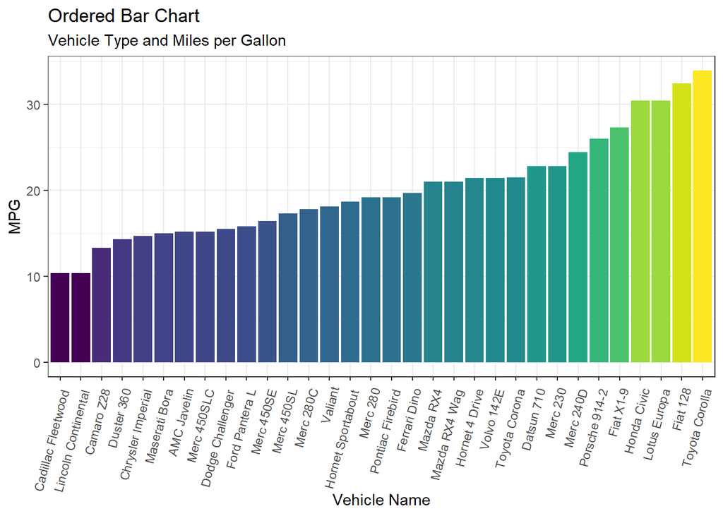

```r
bar1 <- ggplot(mtcars, aes(x = reorder(car_name, mpg), y = mpg)) +
  geom_bar(aes(fill = mpg), stat = "identity") +
  scale_fill_viridis() +
  theme(axis.text.x = element_text(
    angle = 75, hjust = 1.05, vjust = 1),
    legend.position = "none") +
  labs(title = "Ordered Bar Chart",
       subtitle = "Vehicle Type and Miles per Gallon",
       y = "MPG",
       x = "Vehicle Name")
plot(bar1)
```

## Maps

The last form of data visualization we will be reviewing here will be the use of overlaying data on geographic maps. First, we will need to import some data that has relevant geographic information. For our purposes, we are going to use the us_rent_income data. Because I am only interested in rent, I am going to drop the data on income. I am also going to convert the region variable (the name of US states) to lowercase so that merging the data with latitude/longitude data will be easier:

```r
data("us_rent_income")

us_rent <- us_rent_income %>%
  filter(variable != "income")

us_rent$NAME <- tolower(us_rent$NAME)
```

Next, we need to import data that contains information on the latitude and longitude of US states:

```r
mapdata <- map_data("state")
```

Now that we have these two data frames imported, we need to merge the two:

```r
map_data <- left_join(mapdata, us_rent,
                      by = c("region" = "NAME"))
```

While it is not the case within this data set, it is not uncommon to have data that is not represented across all spatial units. For example, consider you had data on rent prices around the world but lacked information on rent in thirty countries. To map exclusively areas where the data is not missing, you can create a new data frame that filters out these NA observations. In this instance, `estimate` (estimated rent) is the column that we are using to filter out observations that contain no information within this column:

```r
map_data_missing <- map_data %>%
  filter(!is.na(map_data$estimate))
```

Now, we will go on to actually create the map. This is a lot of code, so what are we doing in this syntax? For one, we are treating this map as a plot. This explains why we are technically plotting this map as a two-dimensional plot where the x-axis captures longitude and the y-axis captures latitude. However, viewers of a map have little reason to want to know the exact coordinates of a map, especially for a map detailing the information of something like average rent. As a result, we are essentially hiding all information that the x and y axes provide through the use of `theme_void()`.

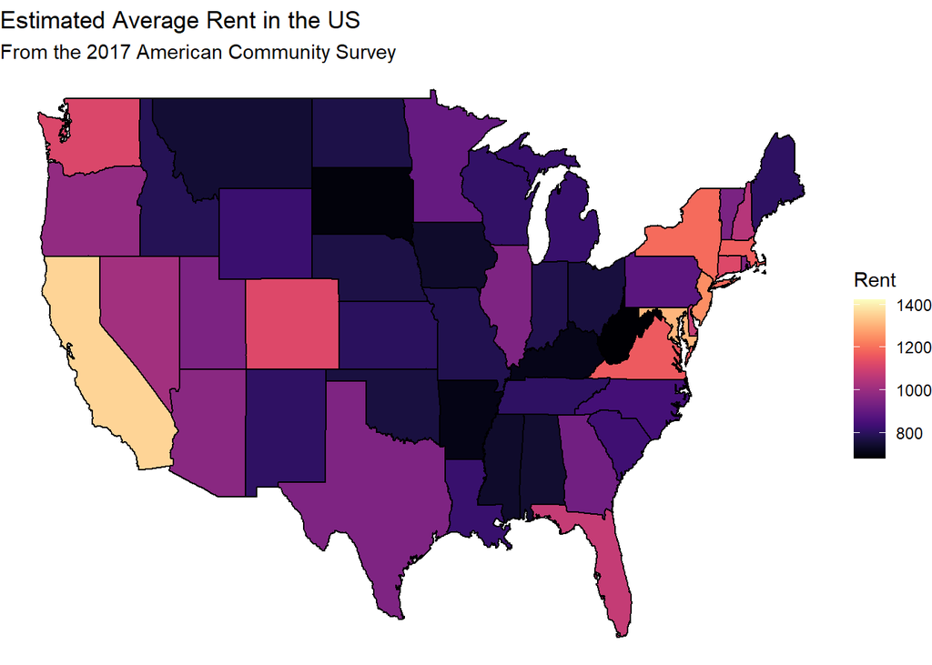

```r
map <- ggplot(map_data, aes(x = long, y = lat, group = group)) +
  geom_polygon(aes(fill = estimate), color = "black") +
  scale_fill_viridis(option = "magma") +
  theme_void() +
  labs(title = "Estimated Average Rent in the US",
       subtitle = "From the 2017 American Community Survey",
       fill = "Rent")
plot(map)
```

## Combining Figures In One Image

We have generated numerous different plots and figures so far. However, to wrap things up, we may be interested in combining these various figures into a common image. The follow syntax details how to do so. To make the total image less cluttered, we are also going to modify some of the pre-existing plots we made:

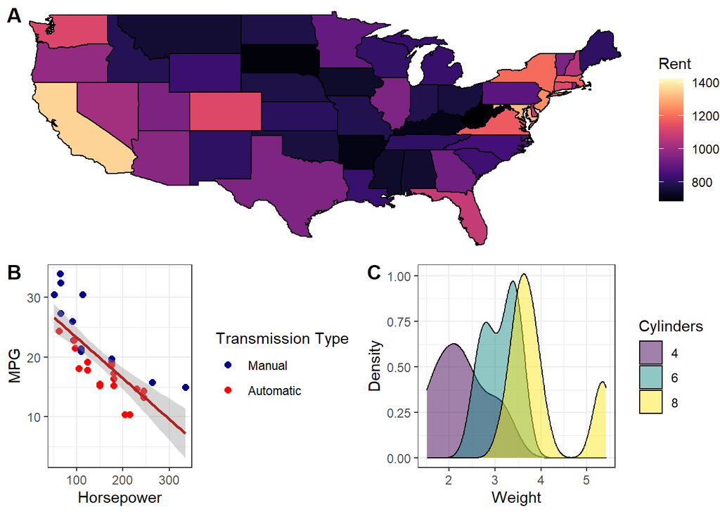

```r
library(ggpubr)

scatter9 <- ggplot(mtcars,
  aes(x = hp, y = mpg)) +
  geom_point(aes(col = factor(am)), size = 2) +
  geom_smooth(method = "lm", col = "firebrick") +
  scale_color_manual(
    name = "Transmission Type",
    labels = c("Manual",
               "Automatic"),
    values = c("1" = "dark blue",
               "0" = "red")) +
  labs(y = "MPG",
       x = "Horsepower")

dens1 <- ggplot(mtcars, aes(x = wt)) +
  scale_fill_viridis(discrete = TRUE) +
  geom_density(aes(fill = factor(cyl)), alpha = 0.5) +
  labs(
    y = "Density",
    x = "Weight",
    fill = "Cylinders")

map <- ggplot(map_data, aes(x = long, y = lat, group = group)) +
  geom_polygon(aes(fill = estimate), color = "black") +
  scale_fill_viridis(option = "magma") +
  theme_void() +
  labs(fill = "Rent")

figure <- ggarrange(map,
                    ggarrange(scatter9, dens1,
                              ncol = 2,
                              labels = c("B", "C")),
                              nrow = 2,
                              labels = "A")
plot(figure)
```

Obviously, you can modify this to your heart’s content. Hopefully this serves as a good introduction to not only `ggarrange`, but also to the capabilities of data visualization in R as a whole. This introduction barely scraped the surface of all of the customization options and types of graphics one can produce in R, but this should serve as a solid baseline!